# PSTAT131_HW1

Andrew Choi

2022-10-29

## Machine Learning Main Ideas

#### Question 1:

Define supervised and unsupervised learning. What are the difference(s) between them?

**Answer:**  
Supervised learning is a subcategory of machine learning used to “accurately predict future response given predictors, understand how predictors affect response, find the”best” model for response given predictors,” and “assess the quality of our predictions and (or) estimation.” (from lecture)

Unsupervised learning is also a subcategory of machine learning used to “discover hidden patterns or data groupings without the need for human intervention.” It is useful when looking for similarities and differences in data. (from https://www.ibm.com/cloud/learn/unsupervised-learning)

The main difference between supervised and unsupervised learning is that supervised learning trains by using labeled data, which means that human intervention is required. Humans are needed to label data appropriately. This labeled data acts as an “answer key” that helps our supervised learning algorithm learn to predict/estimate more accurately. Unsupervised learning does not need labeled data, and instead works with large amounts of unlabeled data to train itself. (from https://www.ibm.com/cloud/blog/supervised-vs-unsupervised-learning)

#### Question 2:

Explain the difference between a regression model and a classification model, specifically in the context of machine learning.

**Answer:**  
“The main difference between Regression and Classification algorithms is that Regression algorithms are used to predict the continuous values such as price, salary, age… and Classification algorithms are used to predict/classify discrete values such as Male or Female, True or False, Spam or Not Spam…” (from https://www.javatpoint.com/regression-vs-classification-in-machine-learning)

#### Question 3:

Name two commonly used metrics for regression ML problems. Name two commonly used metrics for classification ML problems.

**Answer:**  
Two commonly used metrics for regression ML problems include Mean Squared Error (MSE) and R Squared. Two commonly used metrics for classification ML problems include Accuracy and Confusion Matrix. (from https://www.analyticsvidhya.com/blog/2021/05/know-the-best-evaluation-metrics-for-your-regression-model/ and https://www.analyticsvidhya.com/blog/2021/07/metrics-to-evaluate-your-classification-model-to-take-the-right-decisions/)

#### Question 4:

As discussed, statistical models can be used for different purposes. These purposes can generally be classified into the following three categories. Provide a brief description of each.

**Answer:**  
A descriptive model uses mainly unsupervised learning approaches “for outlining, classifying, and drawing out information for what had happened in the past.” (from https://medium.com/appengine-ai/descriptive-analysis-machine-learning-268507a99e2)

An inferential model runs “data points to a machine learning model to calculate an output such as a single numerical score.” (from https://cloud.google.com/bigquery-ml/docs/reference/standard-sql/bigqueryml-syntax-inference-overview#:~:text=Anomaly%20Detection-,Introduction,machine%20learning%20model%20into%20production.%E2%80%9D)

A predictive model uses “machine learning and data mining to predict and forecast lilely future outcomes with the aid of historical and exisitng data.” (from https://www.netsuite.com/portal/resource/articles/financial-management/predictive-modeling.shtml)

#### Question 5:

Define mechanistic. Define empirically-driven. How do these model types differ? How are they similar?

**Answer**  
“A mechanistic model uses a theory to predict what will happen in the real world… Empirical modeling studies real-world events to develop a theory.” While they both have the same components, i.e. they make use of theories and real-world occurrences, the order in which these components are used are opposite. Mechanistic models use theories as inputs and real-world occurrences as outputs, whereas empirical models use real-world occurences as inputs and theories as outputs. (from https://smallbusiness.chron.com/mechanistic-model-12706.html)

In general, is a mechanistic or empirically-driven model easier to understand? Explain your choice.

**Answer**

In my opinion it’s easier to understand an empirically-driven model simply because it’s easier to generate a theory by studying real-world occurrences, than to predict a real-world occurrence using a theory.

Describe how the bias-variance tradeoff is related to the use of mechanistic or empirically-driven models.

**Answer**

Empirical models use individual events to create a generalization. Intuitively, it would make sense that empirical models therefore typically have high variance and low bias. After all, if a function is using individual data points to create a line, it’s much easier for that model to overfit, thus causing high variance and low bias. On the other hand, mechanistic models use theories to predict individual events. If a model uses a very general and broad theory as an input, it can lead to overgeneralizations in the model as well. Thus, mechanistic models can easily underfit, causing high bias and low variance.

#### Question 6:

A political candidate’s campaign has collected some detailed voter history data from their constituents. The campaign is interested in two questions:

1.) Given a voter’s profile/data, how likely is it that they will vote in favor of the candidate?

2.) How would a voter’s likelihood of support for the candidate change if they had personal contact with the candidate?

**Answer**

Question 1.) is a predictive question. This is because it is trying to predict how a voter will vote given a predictor (voter’s profile/data).

Question 2.) is an inferential question. This is because it is trying to determine whether there’s a relationship between two variables.

## Exploratory Data Analysis

**Exercise 1:**

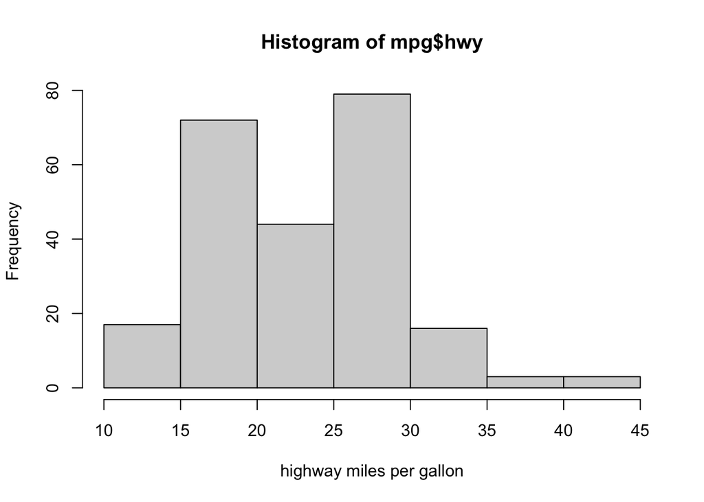

From this information, I’ve learned that cars made between 1999 and 2008 are likely to run between 15 to 30 highway miles per gallon of gasoline.

**Exercise 2:**

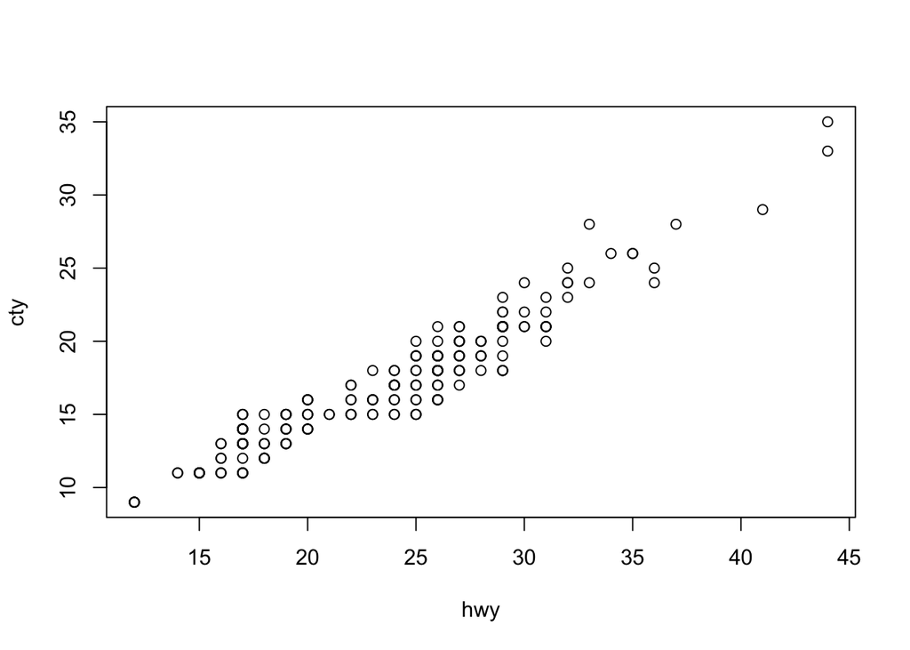

There appears to be a strong positive correlation between the variables hwy and cty. This tells us that as the number of highway miles per gallon of gasoline a car has rises, the number of city miles per gallon of gasoline tends to rise as well. This does not mean that these variables are dependent, they are simply related.

**Exercise 3:**

The following website was used to understand how to order my barplot from highest to lowest values: https://statisticsglobe.com/table

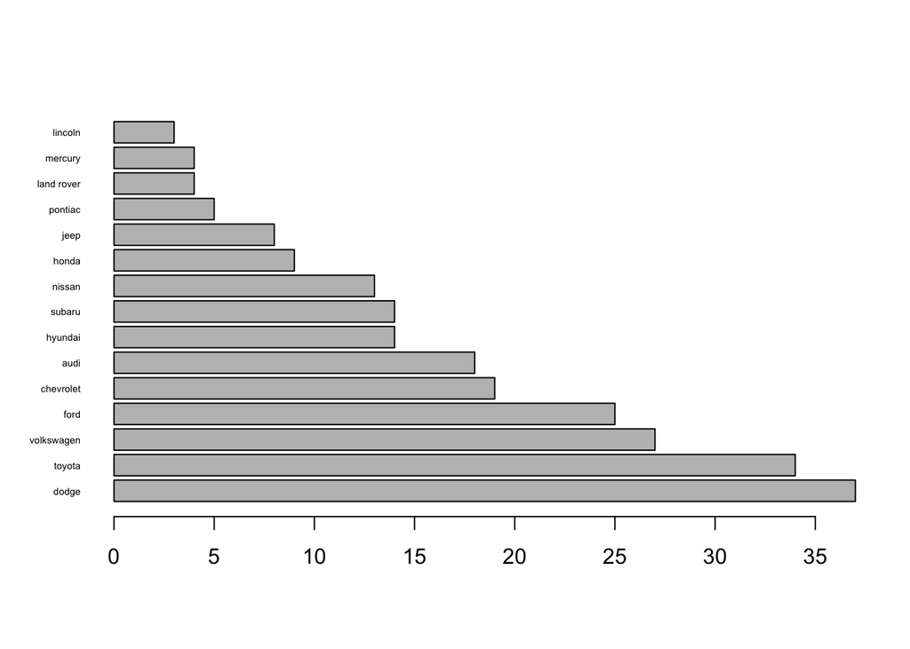

Lincoln produced the least amount of cars, while Dodge produced the most.

**8Exercise 4:**

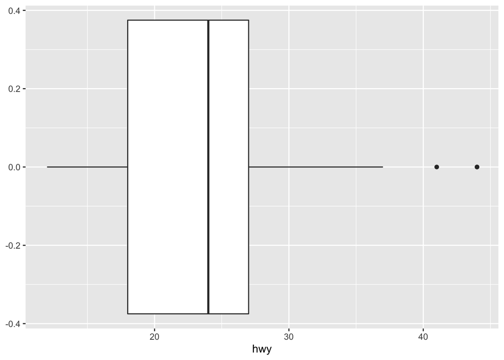

There doesn’t appear to be a pattern.

**Exercise 5:**

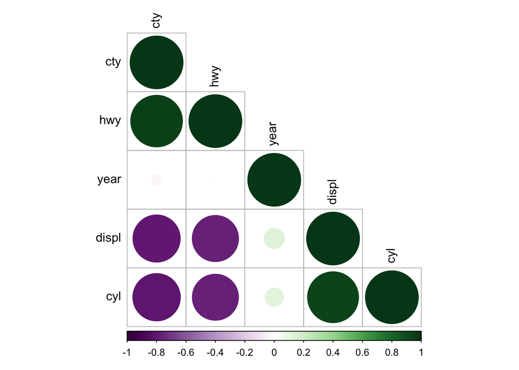

The hwy and cty, and displ and cyl variables are positively correlated with each other. The cyl and cty, displ and cty, cyl and hwy, and displ and hwy are negatively correlated with each other. All of the correlations seem to agree with each other, none of them are unique or surprising.